# Nguyen_Le_Credit_Score_Class

**CREDIT SCORE CLASSIFICATION**

We will be building a model to classify a customer as either "GOOD", "STANDARD", or "POOR" based on their credit score.

The original dataset can be found [here](https://statso.io/credit-score-classification-case-study/).

```python
# import necessary libraries

import numpy as np
import pandas as pd
import matplotlib.pyplot as plt
import seaborn as sns
from sklearn.model_selection import train_test_split
from sklearn.tree import DecisionTreeClassifier
from sklearn.linear_model import LogisticRegression
from sklearn.metrics import confusion_matrix, classification_report, accuracy_score
from sklearn.preprocessing import StandardScaler, LabelEncoder
import xgboost as xgb
import tensorflow as tf
from tensorflow import keras
from sklearn.ensemble import RandomForestClassifier
from imblearn.over_sampling import SMOTE
```

```python
# load dataset
from google.colab import drive
drive.mount('/content/drive')

df = pd.read_csv('/content/drive/MyDrive/Credit_Score_Classification.csv')
```

**EXPLORATORY DATA ANALYSIS**

```python
df.info()
```

```
<class 'pandas.core.frame.DataFrame'>
RangeIndex: 100000 entries, 0 to 99999
Data columns (total 28 columns):
 #   Column                    Non-Null Count   Dtype
---  ------                    --------------   -----
 0   ID                        100000 non-null  int64
 1   Customer_ID               100000 non-null  int64
 2   Month                     100000 non-null  int64
 3   Name                      100000 non-null  object
 4   Age                       100000 non-null  float64
 5   SSN                       100000 non-null  float64
 6   Occupation                100000 non-null  object
 7   Annual_Income             100000 non-null  float64
 8   Monthly_Inhand_Salary     100000 non-null  float64
 9   Num_Bank_Accounts         100000 non-null  float64
```

[output cut: 20 more lines]

```python
df.head()
```

|  | ID | Customer_ID | Month | Name | Age | SSN | Occupation | Annual_Income | Monthly_Inhand_Salary | Num_Bank_Accounts | ... | Credit_Mix | Outstanding_Debt | Credit_Utilization_Ratio | Credit_History_Age | Payment_of_Min_Amount | Total_EMI_per_month | Amount_invested_monthly | Payment_Behaviour | Monthly_Balance | Credit_Score |
| --- | --- | --- | --- | --- | --- | --- | --- | --- | --- | --- | --- | --- | --- | --- | --- | --- | --- | --- | --- | --- | --- |
| 0 | 5634 | 3392 | 1 | Aaron Maashoh | 23.0 | 821000265.0 | Scientist | 19114.12 | 1824.843333 | 3.0 | ... | Good | 809.98 | 26.822620 | 265.0 | No | 49.574949 | 21.46538 | High_spent_Small_value_payments | 312.494089 | Good |
| 1 | 5635 | 3392 | 2 | Aaron Maashoh | 23.0 | 821000265.0 | Scientist | 19114.12 | 1824.843333 | 3.0 | ... | Good | 809.98 | 31.944960 | 266.0 | No | 49.574949 | 21.46538 | Low_spent_Large_value_payments | 284.629162 | Good |
| 2 | 5636 | 3392 | 3 | Aaron Maashoh | 23.0 | 821000265.0 | Scientist | 19114.12 | 1824.843333 | 3.0 | ... | Good | 809.98 | 28.609352 | 267.0 | No | 49.574949 | 21.46538 | Low_spent_Medium_value_payments | 331.209863 | Good |
| 3 | 5637 | 3392 | 4 | Aaron Maashoh | 23.0 | 821000265.0 | Scientist | 19114.12 | 1824.843333 | 3.0 | ... | Good | 809.98 | 31.377862 | 268.0 | No | 49.574949 | 21.46538 | Low_spent_Small_value_payments | 223.451310 | Good |
| 4 | 5638 | 3392 | 5 | Aaron Maashoh | 23.0 | 821000265.0 | Scientist | 19114.12 | 1824.843333 | 3.0 | ... | Good | 809.98 | 24.797347 | 269.0 | No | 49.574949 | 21.46538 | High_spent_Medium_value_payments | 341.489231 | Good |

5 rows × 28 columns

```python
# delete unnecessary columns

df = df.drop(columns=['ID', 'Customer_ID', 'Name', 'SSN'])
```

```python
df.head()
```

|  | Month | Age | Occupation | Annual_Income | Monthly_Inhand_Salary | Num_Bank_Accounts | Num_Credit_Card | Interest_Rate | Num_of_Loan | Type_of_Loan | ... | Credit_Mix | Outstanding_Debt | Credit_Utilization_Ratio | Credit_History_Age | Payment_of_Min_Amount | Total_EMI_per_month | Amount_invested_monthly | Payment_Behaviour | Monthly_Balance | Credit_Score |
| --- | --- | --- | --- | --- | --- | --- | --- | --- | --- | --- | --- | --- | --- | --- | --- | --- | --- | --- | --- | --- | --- |
| 0 | 1 | 23.0 | Scientist | 19114.12 | 1824.843333 | 3.0 | 4.0 | 3.0 | 4.0 | Auto Loan, Credit-Builder Loan, Personal Loan,... | ... | Good | 809.98 | 26.822620 | 265.0 | No | 49.574949 | 21.46538 | High_spent_Small_value_payments | 312.494089 | Good |
| 1 | 2 | 23.0 | Scientist | 19114.12 | 1824.843333 | 3.0 | 4.0 | 3.0 | 4.0 | Auto Loan, Credit-Builder Loan, Personal Loan,... | ... | Good | 809.98 | 31.944960 | 266.0 | No | 49.574949 | 21.46538 | Low_spent_Large_value_payments | 284.629162 | Good |
| 2 | 3 | 23.0 | Scientist | 19114.12 | 1824.843333 | 3.0 | 4.0 | 3.0 | 4.0 | Auto Loan, Credit-Builder Loan, Personal Loan,... | ... | Good | 809.98 | 28.609352 | 267.0 | No | 49.574949 | 21.46538 | Low_spent_Medium_value_payments | 331.209863 | Good |
| 3 | 4 | 23.0 | Scientist | 19114.12 | 1824.843333 | 3.0 | 4.0 | 3.0 | 4.0 | Auto Loan, Credit-Builder Loan, Personal Loan,... | ... | Good | 809.98 | 31.377862 | 268.0 | No | 49.574949 | 21.46538 | Low_spent_Small_value_payments | 223.451310 | Good |
| 4 | 5 | 23.0 | Scientist | 19114.12 | 1824.843333 | 3.0 | 4.0 | 3.0 | 4.0 | Auto Loan, Credit-Builder Loan, Personal Loan,... | ... | Good | 809.98 | 24.797347 | 269.0 | No | 49.574949 | 21.46538 | High_spent_Medium_value_payments | 341.489231 | Good |

5 rows × 24 columns

```python
# Checking number of unique for each 'object' variables

print(df['Occupation'].nunique())
print(df['Type_of_Loan'].nunique())
print(df['Credit_Mix'].nunique())
print(df['Payment_of_Min_Amount'].nunique())
print(df['Payment_Behaviour'].nunique())
```

```
15
6261
3
3
6
```

Type_of_Loan is a collection of different types loans. There are just too many different combinations so I'm just going to delete that column.

```python
df = df.drop(columns=['Type_of_Loan'])
```

**DATA VISUALIZATION**

Taking a look at each feature's relationship to target variable.

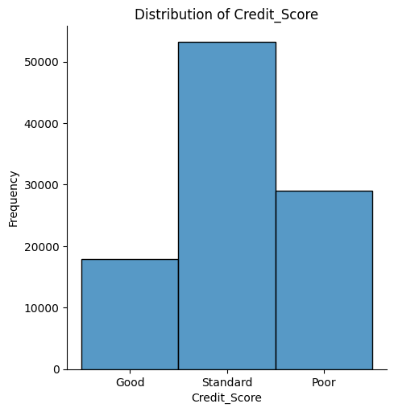

```python
# Create a displot of Credit_Score
plt.figure(figsize=(10, 6))
sns.displot(df['Credit_Score'], bins=30)
plt.title('Distribution of Credit_Score')
plt.xlabel('Credit_Score')
plt.ylabel('Frequency')
plt.show()
```

The target data is imbalanced. We will have to oversample.

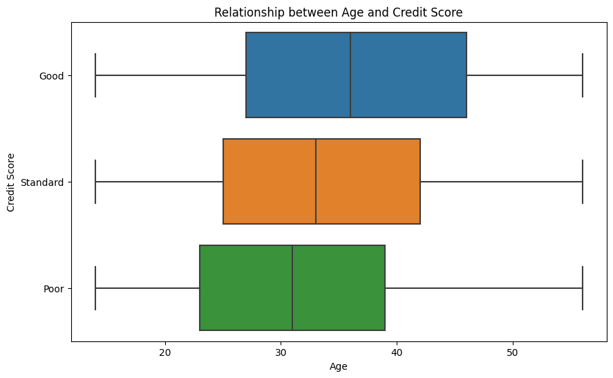

```python
# Age vs Credit_Score
plt.figure(figsize=(10, 6))
sns.boxplot(data=df, x='Age', y='Credit_Score')
plt.title('Relationship between Age and Credit Score')
plt.xlabel('Age')
plt.ylabel('Credit Score')
plt.show()
```

People get better credit scores with age.

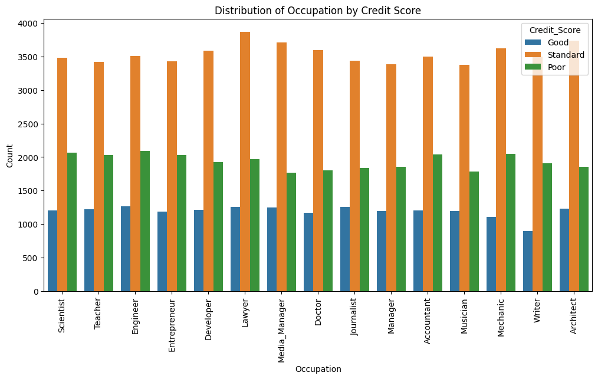

```python
# Occupation vs Credit Score

plt.figure(figsize=(12, 6))
sns.countplot(data=df, x='Occupation', hue='Credit_Score')
plt.title('Distribution of Occupation by Credit Score')
plt.xlabel('Occupation')
plt.ylabel('Count')
plt.xticks(rotation=90)
plt.show()
```

Seems more or less evenly distributed. No correlation.

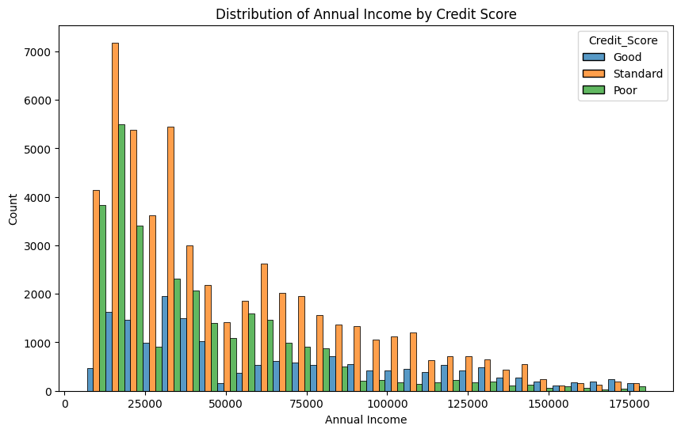

```python
# Annual_Income vs. Credit_Score
plt.figure(figsize=(10, 6))
sns.histplot(data=df, x='Annual_Income', hue='Credit_Score', bins=30, multiple='dodge')
plt.title('Distribution of Annual Income by Credit Score')
plt.xlabel('Annual Income')
plt.ylabel('Count')
plt.show()
```

The lower the annual income, the worse the credit scores. The higher the income, the better the credit scores.

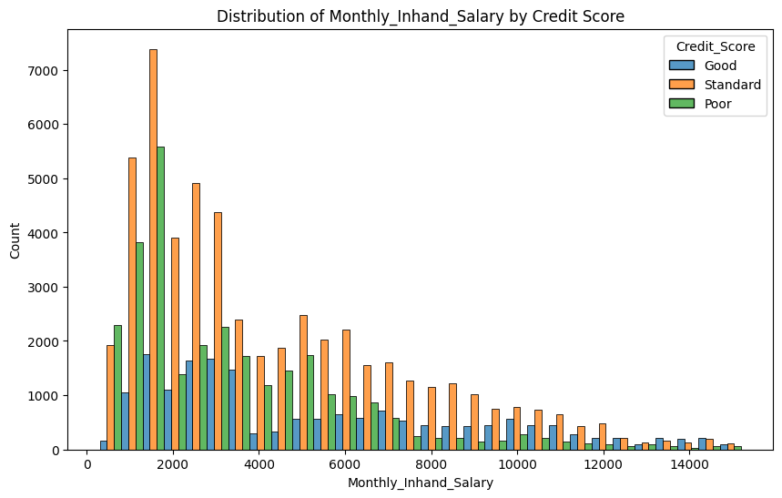

```python
# Monthly_Inhand_Salary vs. Credit_Score
plt.figure(figsize=(10, 6))
sns.histplot(data=df, x='Monthly_Inhand_Salary', hue='Credit_Score', bins=30, multiple='dodge')
plt.title('Distribution of Monthly_Inhand_Salary by Credit Score')
plt.xlabel('Monthly_Inhand_Salary')
plt.ylabel('Count')
plt.show()
```

More money = better scores.

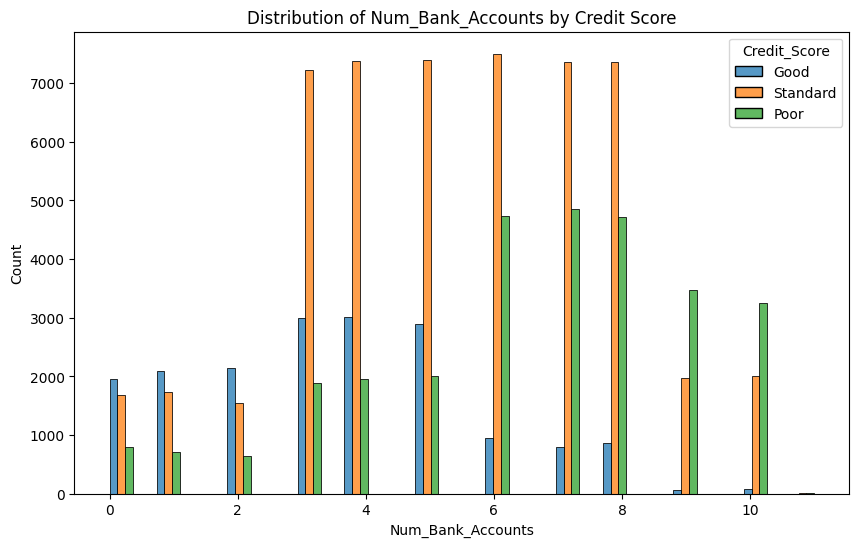

```python
# Num_Bank_Accounts vs credit score

plt.figure(figsize=(10, 6))
sns.histplot(data=df, x='Num_Bank_Accounts', hue='Credit_Score', bins=30, multiple='dodge')
plt.title('Distribution of Num_Bank_Accounts by Credit Score')
plt.xlabel('Num_Bank_Accounts')
plt.ylabel('Count')
plt.show()
```

The fewer the number of accounts, the better the credit scores.

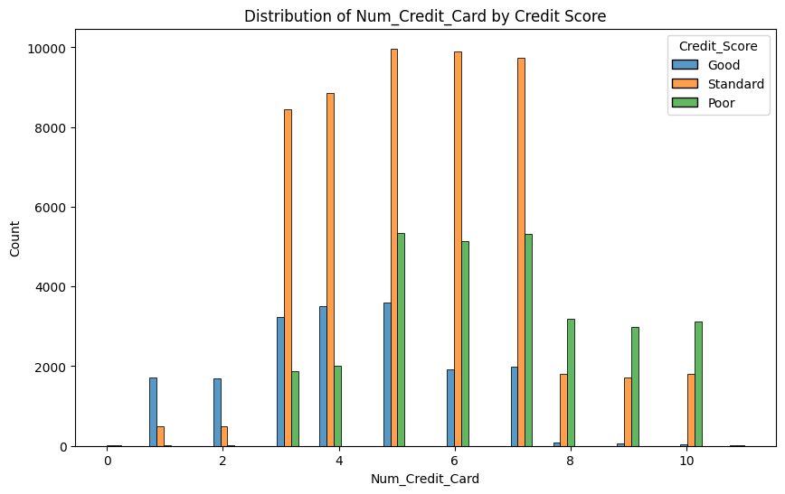

```python
# Num_Credit_Card vs credit score

plt.figure(figsize=(10, 6))
sns.histplot(data=df, x='Num_Credit_Card', hue='Credit_Score', bins=30, multiple='dodge')
plt.title('Distribution of Num_Credit_Card by Credit Score')
plt.xlabel('Num_Credit_Card')
plt.ylabel('Count')
plt.show()
```

Once again, the fewer the credit cards, the better the credit scores.

We are starting to see a pattern here. But for the sake of brevity, I'm going to credit a heatmap to see all correlations.

```python
# One hot encode 'object' variables

df = pd.get_dummies(df, columns=['Occupation', 'Credit_Mix', 'Payment_of_Min_Amount', 'Payment_Behaviour'], drop_first=True)
```

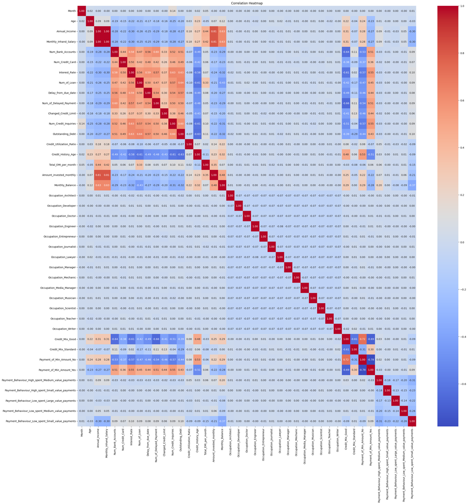

```python
# Compute the correlation matrix
corr_matrix = df.corr()

# Create a heatmap
plt.figure(figsize=(30, 30))
sns.heatmap(corr_matrix, annot=True, fmt=".2f", cmap="coolwarm")
plt.title("Correlation Heatmap")
plt.show()
```

Now that we've seen how each variable correlates to one another, let's go ahead and start building models.

```python
# Define feature columns (X) and target variable (y)
X = df.drop(columns=['Credit_Score'])  # Features
y = df['Credit_Score']  # Target variable

# Split the data into a 70% training set and a 30% testing set while stratifying by 'Credit_Score'
X_train_1, X_test, y_train_1, y_test = train_test_split(X, y, test_size=0.3, random_state=42, stratify=y)

# Instantiate the SMOTE object
smote = SMOTE(random_state=42)

# Fit and apply SMOTE to the training data
X_train, y_train = smote.fit_resample(X_train_1, y_train_1)

# Print the shapes of the resulting sets
print("X_train shape:", X_train.shape)
print("X_test shape:", X_test.shape)
print("y_train shape:", y_train.shape)
print("y_test shape:", y_test.shape)
```

```
X_train shape: (111666, 41)
X_test shape: (30000, 41)
y_train shape: (111666,)
y_test shape: (30000,)
```

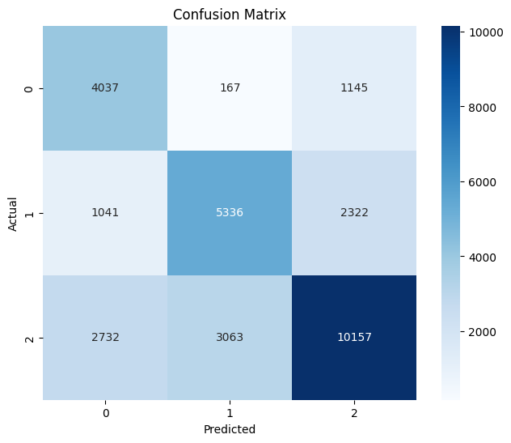

```
Classification Report:
               precision    recall  f1-score   support

        Good       0.52      0.75      0.61      5349
        Poor       0.62      0.61      0.62      8699
    Standard       0.75      0.64      0.69     15952

    accuracy                           0.65     30000
   macro avg       0.63      0.67      0.64     30000
weighted avg       0.67      0.65      0.65     30000

Rounded Accuracy: 0.65
```

```python
# Create a StandardScaler instance
scaler = StandardScaler()

# Fit the scaler on the training data and transform both training and testing data
X_train_scaled = scaler.fit_transform(X_train)
X_test_scaled = scaler.transform(X_test)

# Create and train the Logistic Regression model using scaled features
logistic_regression_model = LogisticRegression(random_state=42, max_iter=500)
logistic_regression_model.fit(X_train_scaled, y_train)

# Make predictions on the scaled test data
y_pred = logistic_regression_model.predict(X_test_scaled)

# Create a confusion matrix
confusion_mat = confusion_matrix(y_test, y_pred)

# Plot the confusion matrix
plt.figure(figsize=(8, 6))
sns.heatmap(confusion_mat, annot=True, fmt="d", cmap="Blues", square=True)
plt.xlabel("Predicted")
plt.ylabel("Actual")
plt.title("Confusion Matrix")
plt.show()

# Print classification report
classification_rep = classification_report(y_test, y_pred)
print("Classification Report:\n", classification_rep)

# Print accuracy score
accuracy = accuracy_score(y_test, y_pred)

print(f"Rounded Accuracy: {accuracy_score(y_test, y_pred):.2f}")
```

Let's try a different model.

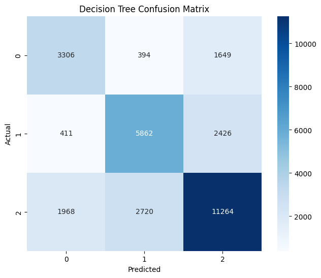

```
Classification Report:
               precision    recall  f1-score   support

        Good       0.58      0.62      0.60      5349
        Poor       0.65      0.67      0.66      8699
    Standard       0.73      0.71      0.72     15952

    accuracy                           0.68     30000
   macro avg       0.66      0.67      0.66     30000
weighted avg       0.68      0.68      0.68     30000

Decision Tree Accuracy: 0.6810666666666667
```

```python
# Create and train the Decision Tree model
decision_tree_model = DecisionTreeClassifier(random_state=42)
decision_tree_model.fit(X_train_scaled, y_train)

# Make predictions on the scaled test data
y_pred_tree = decision_tree_model.predict(X_test_scaled)

# Create a confusion matrix
confusion_mat_tree = confusion_matrix(y_test, y_pred_tree)

# Plot the confusion matrix
plt.figure(figsize=(8, 6))
sns.heatmap(confusion_mat_tree, annot=True, fmt="d", cmap="Blues", square=True)
plt.xlabel("Predicted")
plt.ylabel("Actual")
plt.title("Decision Tree Confusion Matrix")
plt.show()

# Print classification report
classification_rep = classification_report(y_test, y_pred_tree)
print("Classification Report:\n", classification_rep)

# Calculate and print the accuracy score
accuracy_tree = accuracy_score(y_test, y_pred_tree)
print("Decision Tree Accuracy:", accuracy_tree)
```

Slightly better scores overall.

Let's try XGBoost next.

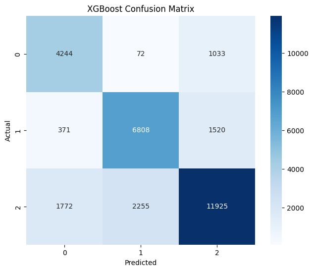

```
XGBoost Classification Report:
               precision    recall  f1-score   support

        Good       0.66      0.79      0.72      5349
        Poor       0.75      0.78      0.76      8699
    Standard       0.82      0.75      0.78     15952

    accuracy                           0.77     30000
   macro avg       0.74      0.77      0.76     30000
weighted avg       0.77      0.77      0.77     30000

XGBoost Accuracy: 0.7659
```

```python
# Create a label encoder instance
label_encoder = LabelEncoder()

# Encode the string labels during model training
y_train_encoded = label_encoder.fit_transform(y_train)

# Create and train the XGBoost model
xgb_model = xgb.XGBClassifier(random_state=42)
xgb_model.fit(X_train_scaled, y_train_encoded)

# Make predictions on the scaled test data
y_pred_xgb_encoded = xgb_model.predict(X_test_scaled)

# For evaluation, use the label encoder to decode the predictions
y_pred_xgb_original = label_encoder.inverse_transform(y_pred_xgb_encoded)

# Create a confusion matrix
confusion_mat_xgb = confusion_matrix(y_test, y_pred_xgb_original)

# Plot the confusion matrix
plt.figure(figsize=(8, 6))
sns.heatmap(confusion_mat_xgb, annot=True, fmt="d", cmap="Blues", square=True)
plt.xlabel("Predicted")
plt.ylabel("Actual")
plt.title("XGBoost Confusion Matrix")
plt.show()

# Print classification report
classification_rep_xgb = classification_report(y_test, y_pred_xgb_original)
print("XGBoost Classification Report:\n", classification_rep_xgb)

# Calculate and print the accuracy score
accuracy_xgb = accuracy_score(y_test, y_pred_xgb_original)
print("XGBoost Accuracy:", accuracy_xgb)
```

A slightly better score. But we can do better.

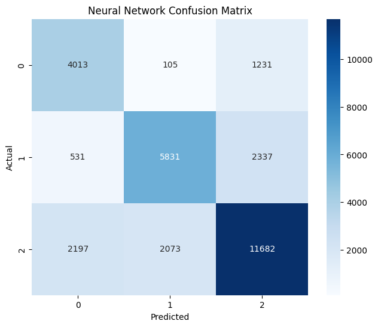

```
Neural Network Classification Report:
               precision    recall  f1-score   support

        Good       0.60      0.75      0.66      5349
        Poor       0.73      0.67      0.70      8699
    Standard       0.77      0.73      0.75     15952

    accuracy                           0.72     30000
   macro avg       0.70      0.72      0.70     30000
weighted avg       0.72      0.72      0.72     30000

Neural Network Accuracy: 0.7175333333333334
```

```python
# Create a label encoder instance
label_encoder = LabelEncoder()

# Encode the string labels during model training
y_train_encoded = label_encoder.fit_transform(y_train)

# Encode the string labels for the test set
y_test_encoded = label_encoder.transform(y_test)

# Create a simple neural network model
model = keras.Sequential([
    keras.layers.Input(shape=(X_train_scaled.shape[1],)),  # Input layer
    keras.layers.Dense(64, activation='relu'),  # Hidden layer with 64 units and ReLU activation
    keras.layers.Dense(64, activation='relu'),  # Hidden layer with 64 units and ReLU activation
    keras.layers.Dense(3, activation='softmax')  # Output layer with 3 units and softmax activation
])

# Compile the model
model.compile(optimizer='adam', loss='sparse_categorical_crossentropy', metrics=['accuracy'])

# Train the model
history = model.fit(X_train_scaled, y_train_encoded, epochs=30, batch_size=32, validation_split=0.2, verbose=1)

# Make predictions on the scaled test data
y_pred_nn_encoded = model.predict(X_test_scaled)
y_pred_nn_encoded = y_pred_nn_encoded.argmax(axis=1)  # Convert softmax probabilities to class labels

# For evaluation, use the label encoder to decode the predictions
y_pred_nn_original = label_encoder.inverse_transform(y_pred_nn_encoded)

# Create a confusion matrix
confusion_mat_nn = confusion_matrix(y_test_encoded, y_pred_nn_encoded)

# Plot the confusion matrix
plt.figure(figsize=(8, 6))
sns.heatmap(confusion_mat_nn, annot=True, fmt="d", cmap="Blues", square=True)
plt.xlabel("Predicted")
plt.ylabel("Actual")
plt.title("Neural Network Confusion Matrix")
plt.show()

# Print classification report
classification_rep_nn = classification_report(y_test_encoded, y_pred_nn_encoded, target_names=label_encoder.classes_)
print("Neural Network Classification Report:\n", classification_rep_nn)

# Calculate and print the accuracy score
accuracy_nn = accuracy_score(y_test_encoded, y_pred_nn_encoded)
print("Neural Network Accuracy:", accuracy_nn)
```

Not that great. Let's try a random forest.

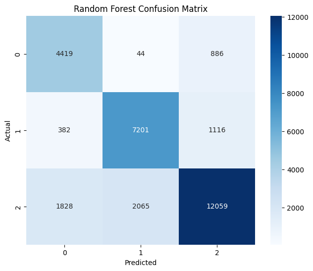

```
Random Forest Classification Report:
               precision    recall  f1-score   support

        Good       0.67      0.83      0.74      5349
        Poor       0.77      0.83      0.80      8699
    Standard       0.86      0.76      0.80     15952

    accuracy                           0.79     30000
   macro avg       0.77      0.80      0.78     30000
weighted avg       0.80      0.79      0.79     30000

Random Forest Accuracy: 0.79
```

```python
# Create and train a Random Forest Classifier
rf_model = RandomForestClassifier(n_estimators=100, random_state=42)
rf_model.fit(X_train_scaled, y_train_encoded)

# Make predictions on the scaled test data
y_pred_rf_encoded = rf_model.predict(X_test_scaled)

# For evaluation, use the label encoder to decode the predictions
y_pred_rf_original = label_encoder.inverse_transform(y_pred_rf_encoded)

# Create a confusion matrix
confusion_mat_rf = confusion_matrix(y_test_encoded, y_pred_rf_encoded)

# Plot the confusion matrix
plt.figure(figsize=(8, 6))
sns.heatmap(confusion_mat_rf, annot=True, fmt="d", cmap="Blues", square=True)
plt.xlabel("Predicted")
plt.ylabel("Actual")
plt.title("Random Forest Confusion Matrix")
plt.show()

# Calculate the accuracy score
accuracy_rf = accuracy_score(y_test_encoded, y_pred_rf_encoded)

# Print classification report
classification_rep_rf = classification_report(y_test_encoded, y_pred_rf_encoded, target_names=label_encoder.classes_)
print("Random Forest Classification Report:\n", classification_rep_rf)

# Calculate and print the accuracy score
rounded_accuracy_rf = round(accuracy_rf, 2)
print("Random Forest Accuracy:", rounded_accuracy_rf)
```

This is great but I have a hunch we can get even better results with the un-oversampled dataset.

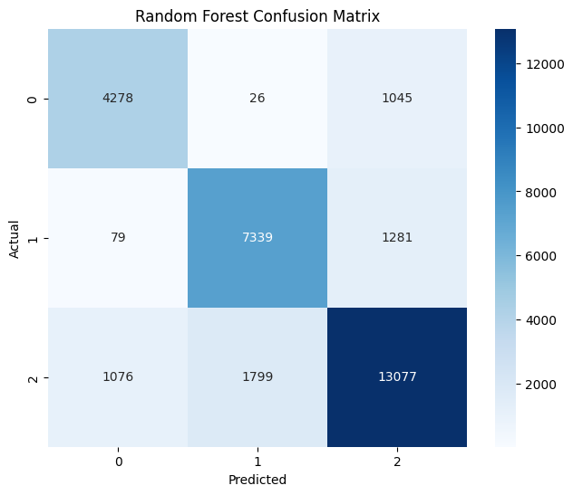

```
Random Forest Classification Report:
               precision    recall  f1-score   support

        Good       0.79      0.80      0.79      5349
        Poor       0.80      0.84      0.82      8699
    Standard       0.85      0.82      0.83     15952

    accuracy                           0.82     30000
   macro avg       0.81      0.82      0.82     30000
weighted avg       0.82      0.82      0.82     30000

Random Forest Accuracy: 0.82
```

```python
# Split the data into a 70% training set and a 30% testing set while stratifying by 'Credit_Score'
X_train_o, X_test_o, y_train_o, y_test_o = train_test_split(X, y, test_size=0.3, random_state=42, stratify=y)

# Create a StandardScaler instance
scaler = StandardScaler()

# Fit the scaler on the training data and transform both training and testing data
X_train_o_scaled = scaler.fit_transform(X_train_o)
X_test_o_scaled = scaler.transform(X_test_o)

# Create a label encoder instance
label_encoder = LabelEncoder()

# Encode the string labels during model training
y_train_o_encoded = label_encoder.fit_transform(y_train_o)

# Encode the string labels for the test set
y_test_o_encoded = label_encoder.transform(y_test_o)

# Create and train a Random Forest Classifier
rf_model = RandomForestClassifier(n_estimators=100, random_state=42)
rf_model.fit(X_train_o_scaled, y_train_o_encoded)

# Make predictions on the scaled test data
y_pred_rf_encoded = rf_model.predict(X_test_o_scaled)

# For evaluation, use the label encoder to decode the predictions
y_pred_rf_original = label_encoder.inverse_transform(y_pred_rf_encoded)

# Create a confusion matrix
confusion_mat_rf = confusion_matrix(y_test_o_encoded, y_pred_rf_encoded)

# Plot the confusion matrix
plt.figure(figsize=(8, 6))
sns.heatmap(confusion_mat_rf, annot=True, fmt="d", cmap="Blues", square=True)
plt.xlabel("Predicted")
plt.ylabel("Actual")
plt.title("Random Forest Confusion Matrix")
plt.show()

# Calculate the accuracy score
accuracy_rf = accuracy_score(y_test_o_encoded, y_pred_rf_encoded)

# Print classification report
classification_rep_rf = classification_report(y_test_o_encoded, y_pred_rf_encoded, target_names=label_encoder.classes_)
print("Random Forest Classification Report:\n", classification_rep_rf)

# Calculate and print the accuracy score
rounded_accuracy_rf = round(accuracy_rf, 2)
print("Random Forest Accuracy:", rounded_accuracy_rf)
```

This is the best model. Let's wrap things up here.

```python
importances = rf_model.feature_importances_

# Create a DataFrame to store feature names and their importances
feature_importances = pd.DataFrame({'Feature': X.columns, 'Importance': importances})

# Sort the features by importance in descending order
feature_importances = feature_importances.sort_values(by='Importance', ascending=False)

# Print the sorted feature importances
print("Feature Importances (Descending Order):")
print(feature_importances)
```

```
Feature Importances (Descending Order):
                                              Feature  Importance
12                                   Outstanding_Debt    0.098220
6                                       Interest_Rate    0.070979
14                                 Credit_History_Age    0.060035
8                                 Delay_from_due_date    0.056815
10                               Changed_Credit_Limit    0.053715
17                                    Monthly_Balance    0.044510
32                                    Credit_Mix_Good    0.042966
13                           Credit_Utilization_Ratio    0.042071
33                                Credit_Mix_Standard    0.040851
11                               Num_Credit_Inquiries    0.040685
15                                Total_EMI_per_month    0.040159
2                                       Annual_Income    0.038888
16                            Amount_invested_monthly    0.038110
```

[output cut: 28 more lines]

Based the feature importances above, we have created a model with 82% accuracy at predicting a customer's credit rating. With high recall scores for all 3 categories.

Let's try something different. That's train a model using a dataframe that only contains top 10 of the important features.

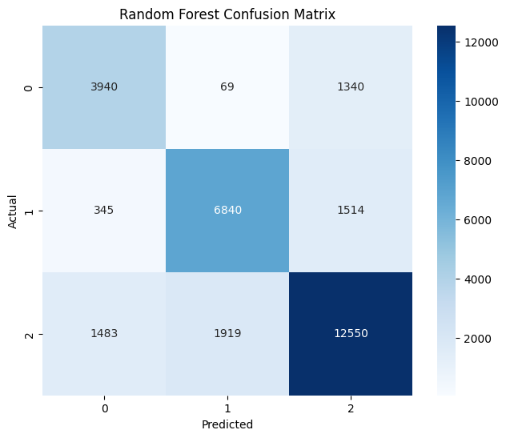

```
Random Forest Classification Report:
               precision    recall  f1-score   support

        Good       0.68      0.74      0.71      5349
        Poor       0.77      0.79      0.78      8699
    Standard       0.81      0.79      0.80     15952

    accuracy                           0.78     30000
   macro avg       0.76      0.77      0.76     30000
weighted avg       0.78      0.78      0.78     30000

Random Forest Accuracy: 0.78
```

```python
# Select the top 10 features by importance
top_features = feature_importances.head(10)

# Create a new DataFrame with the selected features and the target label
df_2 = df[top_features['Feature'].tolist() + ['Credit_Score']]

# Split the data into a 70% training set and a 30% testing set while stratifying by 'Credit_Score'
X_train_o, X_test_o, y_train_o, y_test_o = train_test_split(df_2.drop('Credit_Score', axis=1), df_2['Credit_Score'], test_size=0.3, random_state=42, stratify=df_2['Credit_Score'])

# Create a StandardScaler instance
scaler = StandardScaler()

# Fit the scaler on the training data and transform both training and testing data
X_train_o_scaled = scaler.fit_transform(X_train_o)
X_test_o_scaled = scaler.transform(X_test_o)

# Create a label encoder instance
label_encoder = LabelEncoder()

# Encode the string labels during model training
y_train_o_encoded = label_encoder.fit_transform(y_train_o)

# Encode the string labels for the test set
y_test_o_encoded = label_encoder.transform(y_test_o)

# Create and train a Random Forest Classifier
rf_model = RandomForestClassifier(n_estimators=100, random_state=42)
rf_model.fit(X_train_o_scaled, y_train_o_encoded)

# Make predictions on the scaled test data
y_pred_rf_encoded = rf_model.predict(X_test_o_scaled)

# For evaluation, use the label encoder to decode the predictions
y_pred_rf_original = label_encoder.inverse_transform(y_pred_rf_encoded)

# Create a confusion matrix
confusion_mat_rf = confusion_matrix(y_test_o_encoded, y_pred_rf_encoded)

# Plot the confusion matrix
plt.figure(figsize=(8, 6))
sns.heatmap(confusion_mat_rf, annot=True, fmt="d", cmap="Blues", square=True)
plt.xlabel("Predicted")
plt.ylabel("Actual")
plt.title("Random Forest Confusion Matrix")
plt.show()

# Calculate the accuracy score
accuracy_rf = accuracy_score(y_test_o_encoded, y_pred_rf_encoded)

# Print classification report
classification_rep_rf = classification_report(y_test_o_encoded, y_pred_rf_encoded, target_names=label_encoder.classes_)
print("Random Forest Classification Report:\n", classification_rep_rf)

# Calculate and print the accuracy score
rounded_accuracy_rf = round(accuracy_rf, 2)
print("Random Forest Accuracy:", rounded_accuracy_rf)
```

Meh, it was a nice experiment but the previous model had better results.

```python
%%shell
jupyter nbconvert /content/drive/MyDrive/ColabNotebooks/Colab\ Notebooks/Nguyen_Le_Credit_Score_Class.ipynb --to html
```

```
[NbConvertApp] Converting notebook /content/drive/MyDrive/ColabNotebooks/Colab Notebooks/Nguyen_Le_Credit_Score_Class.ipynb to html
[NbConvertApp] Writing 2112163 bytes to /content/drive/MyDrive/ColabNotebooks/Colab Notebooks/Nguyen_Le_Credit_Score_Class.html
```